# Assignment 6

In this assignment, you'll analyze a collection of data sets from the [San Francisco Open Data Portal](http://data.sfgov.org/) and [Zillow](https://www.zillow.com/). The data sets have been stored in the SQLite database `sf_data.sqlite`, which you can [download here](http://anson.ucdavis.edu/~nulle/sf_data.sqlite). The database contains the following tables:

| Table | Description |
| --- | --- |
| `crime` | Crime reports dating back to 2010. |
| `mobile_food_locations` | List of all locations where mobile food vendors sell. |
| `mobile_food_permits` | List of all mobile food vendor permits. More details [here](https://data.sfgov.org/api/views/rqzj-sfat/files/8g2f5RV4PEk0_b24iJEtgEet9gnh_eA27GlqoOjjK4k?download=true&filename=DPW_DataDictionary_Mobil… |
| `mobile_food_schedule` | Schedules for mobile food vendors. |
| `noise` | Noise complaints dating back to August 2015. |
| `parking` | List of all parking lots. |
| `parks` | List of all parks. |
| `schools` | List of all schools. |
| `zillow` | Zillow rent and housing statistics dating back to 1996. More details [here](https://www.zillow.com/research/data/). |

The `mobile_food_` tables are explicitly connected through the `locationid` and `permit` columns. The other tables are not connected, but you may be able to connect them using dates, latitude/longitude, or postal codes.

Shapefiles for US postal codes are available [here](https://www.census.gov/geo/maps-data/data/cbf/cbf_zcta.html). These may be useful for converting latitude/longitude to postal codes.

Shapefiles for San Francisco Neighborhoods are available [here](https://data.sfgov.org/Geographic-Locations-and-Boundaries/SF-Find-Neighborhoods/pty2-tcw4).

**Exercise 1.1.** Which mobile food vendor(s) sells at the most locations?

```python
import pandas as pd
from matplotlib import pyplot as plt
import sqlalchemy as sqla
import sqlite3
%matplotlib inline
plt.style.use('ggplot')
```

```python
sqlite_file = '/Users/krystal/Desktop/sf_data.sqlite'
sfdata = sqla.create_engine('sqlite:///' + sqlite_file)
```

```python
mobile_food_locations = pd.read_sql_query('select * from mobile_food_locations where Longitude < 0', sfdata)
mobile_food_locations.head()
```

|  | locationid | LocationDescription | Address | Latitude | Longitude |
| --- | --- | --- | --- | --- | --- |
| 0 | 762182 | TOWNSEND ST: 05TH ST to 06TH ST (400 - 499) | 444 TOWNSEND ST | 37.774871 | -122.398532 |
| 1 | 437211 | MISSOURI ST: 20TH ST to SIERRA ST (500 - 630) | 555 MISSOURI ST | 37.759304 | -122.395902 |
| 2 | 765880 | 17TH ST: SAN BRUNO AVE to UTAH ST (2200 - 2299) | 2222 17TH ST | 37.765216 | -122.406007 |
| 3 | 765690 | CESAR CHAVEZ ST: EVANS AVE to KANSAS ST (2100 ... | 2323 CESAR CHAVEZ ST | 37.748801 | -122.400552 |
| 4 | 751253 | FOLSOM ST: 14TH ST to 15TH ST (1800 - 1899) | 1800 FOLSOM ST | 37.767852 | -122.416105 |

```python
mobile_food_permits = pd.read_sql_query('select * from mobile_food_permits', sfdata)
mobile_food_permits.head()
```

|  | permit | Status | Applicant | FacilityType | FoodItems | PriorPermit | Approved | Expiration |
| --- | --- | --- | --- | --- | --- | --- | --- | --- |
| 0 | 16MFF-0027 | APPROVED | F & C Catering | Truck | Cold Truck: Hot/Cold Sandwiches: Water: Soda: ... | 1 | 2016-03-09 12:00:00 | 2017-03-15 12:00:00 |
| 1 | 13MFF-0102 | EXPIRED | Natan's Catering | Truck | Burgers: melts: hot dogs: burritos:sandwiches:... | 1 | 2013-04-12 12:00:00 | 2014-03-15 12:00:00 |
| 2 | 16MFF-0069 | APPROVED | Munch A Bunch | Truck | Cold Truck: packaged sandwiches: pitas: breakf... | 1 | 2016-03-15 12:00:00 | 2017-03-15 12:00:00 |
| 3 | 16MFF-0051 | APPROVED | Park's Catering | Truck | Cold Truck: Hamburger: cheeseburgers: hot dogs... | 1 | 2016-03-15 12:00:00 | 2017-03-15 12:00:00 |
| 4 | 16MFF-0010 | REQUESTED | Pipo's Grill | Truck | Tacos: Burritos: Hot Dogs: and Hamburgers | 0 | None | None |

```python
mobile_food_schedule = pd.read_sql_query('select * from mobile_food_schedule', sfdata)
mobile_food_schedule.head()
```

|  | locationid | permit | DayOfWeek | EndHour | StartHour |
| --- | --- | --- | --- | --- | --- |
| 0 | 305727 | 11MFF-0040 | Mo | 15 | 10 |
| 1 | 305727 | 11MFF-0040 | Tu | 15 | 10 |
| 2 | 305727 | 11MFF-0040 | We | 15 | 10 |
| 3 | 305727 | 11MFF-0040 | Th | 15 | 10 |
| 4 | 305727 | 11MFF-0040 | Fr | 15 | 10 |

```python
sql_query = """
select p.permit, Applicant, count(distinct locationid) number_of_locations
from mobile_food_permits p
inner join mobile_food_schedule s on s.permit = p.permit
where Status = 'APPROVED'
group by p.permit
order by "number_of_locations" desc
"""
location_count = pd.read_sql_query(sql_query, sfdata)
location_count
```

|  | permit | Applicant | number_of_locations |
| --- | --- | --- | --- |
| 0 | 16MFF-0051 | Park's Catering | 23 |
| 1 | 16MFF-0037 | D & T Catering | 17 |
| 2 | 16MFF-0027 | F & C Catering | 13 |
| 3 | 16MFF-0069 | Munch A Bunch | 10 |
| 4 | 16MFF-0019 | Linda's Catering | 7 |
| 5 | 16MFF-0053 | Eva's Catering | 7 |
| 6 | 17MFF-0125 | BH & MT LLC | 7 |
| 7 | 16MFF-0047 | Golden Catering | 5 |
| 8 | 16MFF-0046 | DO UC US Mobile Catering | 4 |
| 9 | 16MFF-0096 | Subs on Hubs | 4 |
| 10 | 16MFF-0032 | Tacos Rodriguez | 3 |
| 11 | 16MFF-0071 | San Pancho's Tacos | 3 |
| 12 | 16MFF-0142 | Bay Area Mobile Catering, Inc. dba. Taqueria A... | 3 |
| 13 | 15MFF-0009 | Maiwand Halal Kabob Truck | 2 |
| 14 | 15MFF-0138 | HALAL SF GYRO | 2 |
| 15 | 15MFF-0141 | Halal Cart of San Francisco | 2 |
| 16 | 16MFF-0024 | Off the Grid Services, LLC | 2 |
| 17 | 16MFF-0095 | Tres Agaves Mexican Kitchen & Tequila Lounge L... | 2 |
| 18 | 16MFF-0119 | El Tonayense #60 | 2 |
| 19 | 16MFF-0120 | Let's Be Frank | 2 |
| 20 | 17MFF-0009 | Slider Shack, LLC. | 2 |
| 21 | 17MFF-0080 | Hiyaaa | 2 |
| 22 | 15MFF-0023 | Peruchi Food Truck,LLC | 1 |
| 23 | 15MFF-0132 | Plaza Garibaldy | 1 |
| 24 | 15MFF-0136 | The Huge Hotdog Concession | 1 |
| 25 | 15MFF-0143 | Ruru Soul | 1 |
| 26 | 15MFF-0151 | El Calamar Perubian Food Truck | 1 |
| 27 | 15MFF-0156 | Roadside Rotisserie Corporation / Country Grill | 1 |
| 28 | 16MFF-0007 | Roadside Rotisserie Corporation / Country Grill | 1 |
| 29 | 16MFF-0008 | Buenafe | 1 |
| ... | ... | ... | ... |
| 32 | 16MFF-0034 | Senor Sisig | 1 |
| 33 | 16MFF-0036 | Roadside Rotisserie Corporation / Country Grill | 1 |
| 34 | 16MFF-0038 | Expresso Subito, LLC. | 1 |
| 35 | 16MFF-0044 | Senor Sisig | 1 |
| 36 | 16MFF-0049 | Got Snacks | 1 |
| 37 | 16MFF-0055 | Eva's Catering | 1 |
| 38 | 16MFF-0056 | San Francisco Carts & Concessions, Inc. DBA St... | 1 |
| 39 | 16MFF-0057 | Stanley Roth | 1 |
| 40 | 16MFF-0058 | San Francisco Carts & Concessions, Inc. DBA St... | 1 |
| 41 | 16MFF-0062 | San Francisco Carts & Concessions, Inc. DBA St... | 1 |
| 42 | 16MFF-0063 | San Francisco Carts & Concessions, Inc. DBA St... | 1 |
| 43 | 16MFF-0065 | San Francisco Street Foods, Inc. | 1 |
| 44 | 16MFF-0066 | San Francisco Carts & Concessions, Inc. DBA St... | 1 |
| 45 | 16MFF-0068 | El Gallo Jiro | 1 |
| 46 | 16MFF-0076 | BHUK Burger | 1 |
| 47 | 16MFF-0079 | SF Cart Project | 1 |
| 48 | 16MFF-0080 | Alfaro's Truck | 1 |
| 49 | 16MFF-0087 | Think is Good Inc. | 1 |
| 50 | 16MFF-0091 | Faith Sandwich | 1 |
| 51 | 16MFF-0092 | Viet Duong Co., Ltd. | 1 |
| 52 | 16MFF-0109 | The New York Frankfurter Co. of CA, Inc. DBA: ... | 1 |
| 53 | 16MFF-0113 | Kabob Trolley, LLC | 1 |
| 54 | 16MFF-0114 | Tacos El Ojo De Agua | 1 |
| 55 | 16MFF-0117 | Santana ESG, Inc. | 1 |
| 56 | 16MFF-0118 | La Jefa | 1 |
| 57 | 16MFF-0121 | Roadside Rotisserie Corporation / Country Grill | 1 |
| 58 | 16MFF-0124 | El Tonayanse #4 / #36 | 1 |
| 59 | 16MFF-0125 | Eli's Hot Dogs | 1 |
| 60 | 17MFF-0067 | Leo's Hot Dogs | 1 |
| 61 | 17MFF-0126 | Bay Area Mobile Catering, Inc. dba. Taqueria A... | 1 |

62 rows × 3 columns

In this question, I connect tables mobile_food_permits and mobile_food_schedule with the common column permit and calculate the count of locations for each permit and select permit number, Applicant (the name of mobile food vendor) and count of locations from the connected table and sort the location counts from high to low.

As a result, from the final table, we can see that mobile food vendor "Park's Catering" sells at the most locations and the number of locations is 23. "D&T Catering" and "F&C Catering" also sell at many locations, of which the numbers are 17 and 13 respectively.

**Exercise 1.2.** Ask and use the database to analyze 5 questions about San Francisco. For each question, write at least 150 words and support your answer with plots. Make a map for at least 2 of the 5 questions.

You should try to come up with some questions on your own, but these are examples of reasonable questions:

- Which parts of the city are the most and least expensive?
- Which parts of the city are the most dangerous (and at what times)?
- Are noise complaints and mobile food vendors related?
- What are the best times and places to find food trucks?
- Is there a relationship between housing prices and any of the other tables?

Please make sure to clearly state each of your questions in your submission.

**Question1 Which parts of the city and at what times are the most dangerous?**

```python
crime = pd.read_sql_query('select * from crime', sfdata)
crime.head()
```

|  | IncidntNum | Category | Descript | DayOfWeek | Datetime | PdDistrict | Resolution | Address | Lon | Lat |
| --- | --- | --- | --- | --- | --- | --- | --- | --- | --- | --- |
| 0 | 150060275 | NON-CRIMINAL | LOST PROPERTY | Monday | 2015-01-19 14:00:00 | MISSION | NONE | 18TH ST / VALENCIA ST | -122.421582 | 37.761701 |
| 1 | 150098210 | ROBBERY | ROBBERY, BODILY FORCE | Sunday | 2015-02-01 15:45:00 | TENDERLOIN | NONE | 300 Block of LEAVENWORTH ST | -122.414406 | 37.784191 |
| 2 | 150098210 | ASSAULT | AGGRAVATED ASSAULT WITH BODILY FORCE | Sunday | 2015-02-01 15:45:00 | TENDERLOIN | NONE | 300 Block of LEAVENWORTH ST | -122.414406 | 37.784191 |
| 3 | 150098210 | SECONDARY CODES | DOMESTIC VIOLENCE | Sunday | 2015-02-01 15:45:00 | TENDERLOIN | NONE | 300 Block of LEAVENWORTH ST | -122.414406 | 37.784191 |
| 4 | 150098226 | VANDALISM | MALICIOUS MISCHIEF, VANDALISM OF VEHICLES | Tuesday | 2015-01-27 19:00:00 | NORTHERN | NONE | LOMBARD ST / LAGUNA ST | -122.431119 | 37.800469 |

```python
sql_query = """
select count(distinct IncidntNum) number_of_crime, PdDistrict, DayOfWeek
from crime
group by PdDistrict, DayOfWeek
order by "number_of_crime" desc
"""
crime_time_place = pd.read_sql_query(sql_query, sfdata)
crime_time_place
```

|  | number_of_crime | PdDistrict | DayOfWeek |
| --- | --- | --- | --- |
| 0 | 24869 | SOUTHERN | Friday |
| 1 | 23963 | SOUTHERN | Saturday |
| 2 | 22209 | SOUTHERN | Wednesday |
| 3 | 22003 | SOUTHERN | Thursday |
| 4 | 20946 | SOUTHERN | Tuesday |
| 5 | 20815 | SOUTHERN | Sunday |
| 6 | 20541 | SOUTHERN | Monday |
| 7 | 15514 | NORTHERN | Friday |
| 8 | 15350 | NORTHERN | Saturday |
| 9 | 15307 | MISSION | Friday |
| 10 | 15018 | CENTRAL | Saturday |
| 11 | 14826 | MISSION | Saturday |
| 12 | 14341 | CENTRAL | Friday |
| 13 | 14323 | MISSION | Wednesday |
| 14 | 14095 | MISSION | Thursday |
| 15 | 13996 | MISSION | Tuesday |
| 16 | 13944 | MISSION | Sunday |
| 17 | 13752 | NORTHERN | Sunday |
| 18 | 13742 | NORTHERN | Thursday |
| 19 | 13717 | NORTHERN | Wednesday |
| 20 | 13691 | MISSION | Monday |
| 21 | 13341 | NORTHERN | Tuesday |
| 22 | 12998 | NORTHERN | Monday |
| 23 | 12809 | CENTRAL | Sunday |
| 24 | 12124 | CENTRAL | Wednesday |
| 25 | 12110 | CENTRAL | Thursday |
| 26 | 11881 | BAYVIEW | Friday |
| 27 | 11720 | CENTRAL | Monday |
| 28 | 11649 | CENTRAL | Tuesday |
| 29 | 11181 | BAYVIEW | Wednesday |
| ... | ... | ... | ... |
| 41 | 9262 | TARAVAL | Friday |
| 42 | 8841 | TARAVAL | Wednesday |
| 43 | 8840 | INGLESIDE | Sunday |
| 44 | 8732 | TARAVAL | Tuesday |
| 45 | 8632 | TARAVAL | Monday |
| 46 | 8463 | TARAVAL | Thursday |
| 47 | 8421 | TENDERLOIN | Wednesday |
| 48 | 8143 | TENDERLOIN | Tuesday |
| 49 | 8126 | TARAVAL | Saturday |
| 50 | 7976 | TENDERLOIN | Friday |
| 51 | 7950 | TENDERLOIN | Thursday |
| 52 | 7756 | TARAVAL | Sunday |
| 53 | 7671 | TENDERLOIN | Saturday |
| 54 | 7632 | TENDERLOIN | Monday |
| 55 | 7380 | PARK | Friday |
| 56 | 7218 | TENDERLOIN | Sunday |
| 57 | 7154 | PARK | Wednesday |
| 58 | 7023 | RICHMOND | Friday |
| 59 | 6798 | PARK | Thursday |
| 60 | 6739 | PARK | Saturday |
| 61 | 6734 | PARK | Monday |
| 62 | 6679 | PARK | Tuesday |
| 63 | 6546 | RICHMOND | Saturday |
| 64 | 6485 | RICHMOND | Wednesday |
| 65 | 6476 | PARK | Sunday |
| 66 | 6449 | RICHMOND | Thursday |
| 67 | 6325 | RICHMOND | Tuesday |
| 68 | 6177 | RICHMOND | Monday |
| 69 | 6085 | RICHMOND | Sunday |
| 70 | 1 | None | Sunday |

71 rows × 3 columns

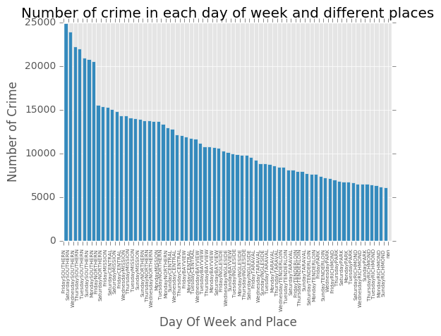

```python
x = range(len(crime_time_place))
labels = crime_time_place['DayOfWeek'] + crime_time_place['PdDistrict']
plt.xticks(x, labels, rotation = 'vertical', size = 5.2)
plt.bar(x, crime_time_place['number_of_crime'])
plt.xlabel('Day Of Week and Place')
plt.ylabel('Number of Crime')
plt.title('Number of crime in each day of week and different places')
plt.show()
```

```python
sql_query = """
select count(distinct IncidntNum) number_of_crime, DayOfWeek
from crime
group by DayOfWeek
order by "number_of_crime" desc
"""
crime_time = pd.read_sql_query(sql_query, sfdata)
crime_time
```

|  | number_of_crime | DayOfWeek |
| --- | --- | --- |
| 0 | 123861 | Friday |
| 1 | 118402 | Saturday |
| 2 | 114583 | Wednesday |
| 3 | 112178 | Thursday |
| 4 | 110484 | Tuesday |
| 5 | 108635 | Monday |
| 6 | 107680 | Sunday |

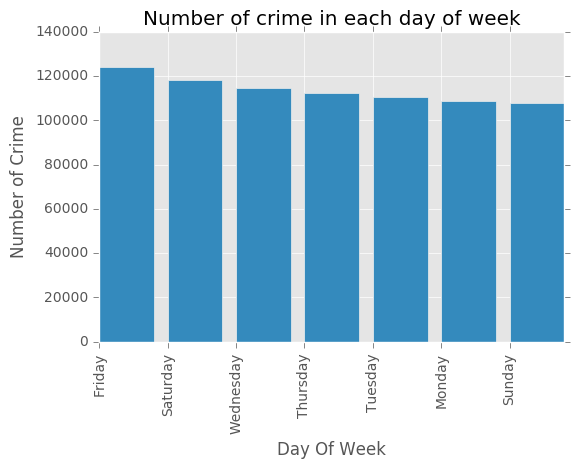

```python
x = range(len(crime_time))
labels = crime_time['DayOfWeek']
plt.xticks(x, labels, rotation = 'vertical')
plt.bar(x, crime_time['number_of_crime'])
plt.xlabel('Day Of Week')
plt.ylabel('Number of Crime')
plt.title('Number of crime in each day of week')
plt.show()
```

In this question, I use table "crime" and select incident number, day of week and district. Then I count the number of distinct incident numbers by district and day of week. I make a bar plot for crime number with time and place and I find that the most dangerous time and part of the city is Friday in Southern district of San Francisco, with a number of crime incidents 24869. I also select only incident number and day of week and calculate the number of distinct incident numbers by day of week. I make a bar plot for crime number with time and and I find that the most dangerous time in San Francisco is Friday, with a number of incidents as high as 123861. As a result, people will have high risk to enroll in a crime incident in Friday and especially in Southern district of San Francisco and they should avoid going out at that time and in that district.

**Question2 Are noise complaints and mobile food vendors related?**

```python
noise = pd.read_sql_query('select * from noise', sfdata)
noise.head()
```

|  | CaseID | Type | Address | Neighborhood | Datetime | Lat | Lon |
| --- | --- | --- | --- | --- | --- | --- | --- |
| 0 | 5130305 | other_excessive_noise | Not associated with a specific address | None | 2015-09-25 00:29:33 | NaN | NaN |
| 1 | 6446138 | amplified_sound_electronics | Intersection of CLINTON PARK and GUERRERO ST | Mission Dolores | 2016-10-21 13:20:18 | 37.769148 | -122.424475 |
| 2 | 5929789 | other_excessive_noise | 1301 48TH AVE, SAN FRANCISCO, CA, 94122 | Outer Sunset | 2016-06-01 11:38:59 | 37.762047 | -122.508365 |
| 3 | 5659943 | other_excessive_noise | 736 LEAVENWORTH ST, SAN FRANCISCO, CA, 94109 | Lower Nob Hill | 2016-03-13 01:18:27 | 37.787983 | -122.414943 |
| 4 | 5930704 | other_excessive_noise | 1360 43RD AVE, SAN FRANCISCO, CA, 94122 | Outer Sunset | 2016-06-01 13:58:43 | 37.761385 | -122.502232 |

```python
sql_query = """
select distinct s.locationid, Latitude, Longitude, s.permit
from mobile_food_locations l
inner join mobile_food_schedule s on s.locationid = l.locationid
inner join mobile_food_permits p on p.permit = s.permit
where Status = 'APPROVED' and Longitude < 0
"""
mobile_vendor_place = pd.read_sql_query(sql_query, sfdata)
mobile_vendor_place
```

|  | locationid | Latitude | Longitude | permit |
| --- | --- | --- | --- | --- |
| 0 | 762178 | 37.753109 | -122.388170 | 16MFF-0027 |
| 1 | 762179 | 37.754252 | -122.389381 | 16MFF-0027 |
| 2 | 762180 | 37.769829 | -122.400101 | 16MFF-0027 |
| 3 | 762181 | 37.780561 | -122.392849 | 16MFF-0027 |
| 4 | 762182 | 37.774871 | -122.398532 | 16MFF-0027 |
| 5 | 762183 | 37.753717 | -122.388359 | 16MFF-0027 |
| 6 | 762184 | 37.755534 | -122.393925 | 16MFF-0027 |
| 7 | 762186 | 37.752242 | -122.389189 | 16MFF-0027 |
| 8 | 762187 | 37.737727 | -122.376573 | 16MFF-0027 |
| 9 | 762188 | 37.742990 | -122.386773 | 16MFF-0027 |
| 10 | 762190 | 37.753381 | -122.386368 | 16MFF-0027 |
| 11 | 765880 | 37.765216 | -122.406007 | 16MFF-0069 |
| 12 | 765881 | 37.763864 | -122.458392 | 16MFF-0069 |
| 13 | 765882 | 37.776381 | -122.406934 | 16MFF-0069 |
| 14 | 765883 | 37.770818 | -122.414007 | 16MFF-0069 |
| 15 | 765884 | 37.788528 | -122.418314 | 16MFF-0069 |
| 16 | 765885 | 37.778494 | -122.422955 | 16MFF-0069 |
| 17 | 765886 | 37.767734 | -122.410153 | 16MFF-0069 |
| 18 | 765889 | 37.767348 | -122.420477 | 16MFF-0069 |
| 19 | 765688 | 37.751691 | -122.394374 | 16MFF-0051 |
| 20 | 765689 | 37.730906 | -122.373303 | 16MFF-0051 |
| 21 | 765690 | 37.748801 | -122.400552 | 16MFF-0051 |
| 22 | 765691 | 37.744752 | -122.385679 | 16MFF-0051 |
| 23 | 765692 | 37.744591 | -122.393077 | 16MFF-0051 |
| 24 | 765693 | 37.746756 | -122.400906 | 16MFF-0051 |
| 25 | 765694 | 37.743784 | -122.403789 | 16MFF-0051 |
| 26 | 765696 | 37.746711 | -122.392150 | 16MFF-0051 |
| 27 | 765697 | 37.746470 | -122.391515 | 16MFF-0051 |
| 28 | 765698 | 37.743713 | -122.385965 | 16MFF-0051 |
| 29 | 765699 | 37.742990 | -122.386773 | 16MFF-0051 |
| ... | ... | ... | ... | ... |
| 120 | 809080 | 37.746948 | -122.403391 | 16MFF-0125 |
| 121 | 735646 | 37.788457 | -122.399884 | 15MFF-0151 |
| 122 | 915986 | 37.771587 | -122.414007 | 16MFF-0142 |
| 123 | 915987 | 37.775228 | -122.417466 | 16MFF-0142 |
| 124 | 915988 | 37.750932 | -122.411420 | 16MFF-0142 |
| 125 | 687419 | 37.767833 | -122.401225 | 15MFF-0143 |
| 126 | 680504 | 37.793149 | -122.402567 | 15MFF-0141 |
| 127 | 680505 | 37.793872 | -122.394865 | 15MFF-0141 |
| 128 | 849883 | 37.793577 | -122.403230 | 16MFF-0121 |
| 129 | 797445 | 37.786856 | -122.406892 | 16MFF-0109 |
| 130 | 911893 | 37.780918 | -122.392417 | 16MFF-0007 |
| 131 | 828062 | 37.788779 | -122.402575 | 15MFF-0156 |
| 132 | 765778 | 37.807743 | -122.424150 | 16MFF-0057 |
| 133 | 765819 | 37.789233 | -122.405579 | 16MFF-0065 |
| 134 | 775804 | 37.766125 | -122.395473 | 16MFF-0008 |
| 135 | 932023 | 37.789119 | -122.395881 | 17MFF-0009 |
| 136 | 932024 | 37.792536 | -122.394593 | 17MFF-0009 |
| 137 | 719119 | 37.777224 | -122.417361 | 15MFF-0138 |
| 138 | 719121 | 37.776736 | -122.416395 | 15MFF-0138 |
| 139 | 844601 | 37.792346 | -122.402385 | 15MFF-0132 |
| 140 | 934405 | 37.780215 | -122.416026 | 17MFF-0080 |
| 141 | 934406 | 37.792367 | -122.400148 | 17MFF-0080 |
| 142 | 936619 | 37.775774 | -122.437332 | 17MFF-0125 |
| 143 | 936620 | 37.783922 | -122.446722 | 17MFF-0125 |
| 144 | 936621 | 37.775290 | -122.440731 | 17MFF-0125 |
| 145 | 936622 | 37.764460 | -122.425161 | 17MFF-0125 |
| 146 | 936623 | 37.766625 | -122.429511 | 17MFF-0125 |
| 147 | 936624 | 37.755031 | -122.384531 | 17MFF-0125 |
| 148 | 934356 | 37.760087 | -122.418806 | 17MFF-0067 |
| 149 | 936872 | 37.749256 | -122.390975 | 17MFF-0126 |

150 rows × 4 columns

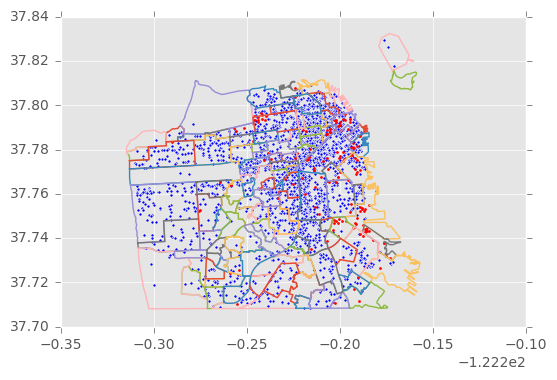

```python
import shapefile as shp
sf = shp.Reader("/Users/krystal/Desktop/SF Find Neighborhoods/geo_export_25779b9a-fec5-4d46-be10-cf787edd6917.shp" )
plt.figure()
for shape in sf.shapeRecords():
    x = [i[0] for i in shape.shape.points[:]]
    y = [i[1] for i in shape.shape.points[:]]
    plt.plot(x,y)
plt.scatter(noise['Lon'], noise['Lat'], s = 5)
plt.scatter(mobile_vendor_place['Longitude'], mobile_vendor_place['Latitude'], color = 'red', s = 2)
plt.show()
```

In this question, I use tables 'noise' and 'mobile_food_locations', and I use the longitude and latitude information in these two tables. To see the relationship between noise complaints and mobile food vendors, I want to draw all the noise complaints points with blue points and all approved mobile food vendors with red points and see their distribution on the shapefile, which is plotted by module called 'shapefile'. From the plot above, I find that in the northeast part of the city, especially in Financial District and South of Market District according to Shapefiles for San Francisco Neighborhoods, noise complaint points distribute around mobile food vendors, however, in other district, noise complaint points seem to distribute far away with mobile food vendors. As a result, noise complaint has relationship with mobile food vendors in Financial District and South of Market District, while in other districts of the city, noise complaint has no relationship with mobile food vendors.

**Question3 What are the best times and places to find food trucks?**

```python
sql_query = """
select count(distinct locationid) num_of_vendors, DayOfWeek
from mobile_food_schedule s
inner join mobile_food_permits p on p.permit = s.permit
where FacilityType = 'Truck' and Status = 'APPROVED'
group by DayOfWeek
order by "num_of_vendors" desc
"""
time_vendors = pd.read_sql_query(sql_query, sfdata)
time_vendors
```

|  | num_of_vendors | DayOfWeek |
| --- | --- | --- |
| 0 | 119 | Fr |
| 1 | 118 | Mo |
| 2 | 118 | We |
| 3 | 116 | Th |
| 4 | 115 | Tu |
| 5 | 22 | Sa |
| 6 | 20 | Su |

```python
sql_query = """
select distinct s.locationid, Latitude, Longitude, s.permit
from mobile_food_locations l
inner join mobile_food_schedule s on s.locationid = l.locationid
inner join mobile_food_permits p on p.permit = s.permit
where DayOfWeek = 'Fr' and Longitude < 0 and FacilityType = 'Truck' and Status = 'APPROVED'
"""
Friday_place = pd.read_sql_query(sql_query, sfdata)
Friday_place
```

|  | locationid | Latitude | Longitude | permit |
| --- | --- | --- | --- | --- |
| 0 | 654163 | 37.793393 | -122.402314 | 15MFF-0009 |
| 1 | 654165 | 37.793214 | -122.397043 | 15MFF-0009 |
| 2 | 676176 | 37.788877 | -122.420091 | 15MFF-0136 |
| 3 | 676797 | 37.796123 | -122.397273 | 15MFF-0023 |
| 4 | 760539 | 37.777755 | -122.394808 | 16MFF-0019 |
| 5 | 760540 | 37.783171 | -122.392901 | 16MFF-0019 |
| 6 | 760541 | 37.779051 | -122.398304 | 16MFF-0019 |
| 7 | 760542 | 37.778148 | -122.394441 | 16MFF-0019 |
| 8 | 760543 | 37.778384 | -122.438782 | 16MFF-0019 |
| 9 | 760544 | 37.786237 | -122.389066 | 16MFF-0019 |
| 10 | 761933 | 37.775589 | -122.397977 | 16MFF-0024 |
| 11 | 762178 | 37.753109 | -122.388170 | 16MFF-0027 |
| 12 | 762179 | 37.754252 | -122.389381 | 16MFF-0027 |
| 13 | 762180 | 37.769829 | -122.400101 | 16MFF-0027 |
| 14 | 762181 | 37.780561 | -122.392849 | 16MFF-0027 |
| 15 | 762182 | 37.774871 | -122.398532 | 16MFF-0027 |
| 16 | 762183 | 37.753717 | -122.388359 | 16MFF-0027 |
| 17 | 762186 | 37.752242 | -122.389189 | 16MFF-0027 |
| 18 | 762187 | 37.737727 | -122.376573 | 16MFF-0027 |
| 19 | 762188 | 37.742990 | -122.386773 | 16MFF-0027 |
| 20 | 762190 | 37.753381 | -122.386368 | 16MFF-0027 |
| 21 | 762513 | 37.790485 | -122.400940 | 16MFF-0032 |
| 22 | 762514 | 37.740995 | -122.401172 | 16MFF-0032 |
| 23 | 762515 | 37.739111 | -122.382465 | 16MFF-0032 |
| 24 | 762516 | 37.752405 | -122.387000 | 16MFF-0033 |
| 25 | 762621 | 37.775826 | -122.417250 | 16MFF-0034 |
| 26 | 763522 | 37.790922 | -122.400100 | 16MFF-0036 |
| 27 | 763588 | 37.796480 | -122.442530 | 16MFF-0037 |
| 28 | 763589 | 37.795316 | -122.439908 | 16MFF-0037 |
| 29 | 763590 | 37.795586 | -122.441718 | 16MFF-0037 |
| ... | ... | ... | ... | ... |
| 76 | 765881 | 37.763864 | -122.458392 | 16MFF-0069 |
| 77 | 765882 | 37.776381 | -122.406934 | 16MFF-0069 |
| 78 | 765883 | 37.770818 | -122.414007 | 16MFF-0069 |
| 79 | 765884 | 37.788528 | -122.418314 | 16MFF-0069 |
| 80 | 765885 | 37.778494 | -122.422955 | 16MFF-0069 |
| 81 | 765886 | 37.767734 | -122.410153 | 16MFF-0069 |
| 82 | 767078 | 37.725577 | -122.454153 | 16MFF-0076 |
| 83 | 769977 | 37.769124 | -122.391475 | 16MFF-0079 |
| 84 | 770163 | 37.767855 | -122.422484 | 16MFF-0080 |
| 85 | 775689 | 37.781689 | -122.391062 | 16MFF-0087 |
| 86 | 792635 | 37.766217 | -122.403953 | 16MFF-0095 |
| 87 | 793872 | 37.778710 | -122.401839 | 16MFF-0096 |
| 88 | 793873 | 37.771402 | -122.391772 | 16MFF-0096 |
| 89 | 793874 | 37.774975 | -122.409386 | 16MFF-0096 |
| 90 | 801849 | 37.780647 | -122.394629 | 16MFF-0114 |
| 91 | 801895 | 37.738727 | -122.406736 | 16MFF-0118 |
| 92 | 802221 | 37.763108 | -122.413455 | 16MFF-0119 |
| 93 | 828062 | 37.788779 | -122.402575 | 15MFF-0156 |
| 94 | 849883 | 37.793577 | -122.403230 | 16MFF-0121 |
| 95 | 915986 | 37.771587 | -122.414007 | 16MFF-0142 |
| 96 | 915987 | 37.775228 | -122.417466 | 16MFF-0142 |
| 97 | 932023 | 37.789119 | -122.395881 | 17MFF-0009 |
| 98 | 934406 | 37.792367 | -122.400148 | 17MFF-0080 |
| 99 | 936619 | 37.775774 | -122.437332 | 17MFF-0125 |
| 100 | 936620 | 37.783922 | -122.446722 | 17MFF-0125 |
| 101 | 936621 | 37.775290 | -122.440731 | 17MFF-0125 |
| 102 | 936622 | 37.764460 | -122.425161 | 17MFF-0125 |
| 103 | 936623 | 37.766625 | -122.429511 | 17MFF-0125 |
| 104 | 936624 | 37.755031 | -122.384531 | 17MFF-0125 |
| 105 | 936872 | 37.749256 | -122.390975 | 17MFF-0126 |

106 rows × 4 columns

```python
import folium
import geopandas as gp
SF_COORDINATES = (37.76, -122.45)
MAX_RECORDS = 1000
mapobj = folium.Map(location = SF_COORDINATES, zoom_start = 13)
feature_group = folium.FeatureGroup("Locations")
for each in Friday_place[0:MAX_RECORDS].iterrows():
    feature_group.add_child(folium.Marker(location = [each[1]['Latitude'], each[1]['Longitude']]))
mapobj.add_child(feature_group)

districts = gp.GeoDataFrame.from_file(
    '/Users/krystal/Desktop/SF Find Neighborhoods/geo_export_25779b9a-fec5-4d46-be10-cf787edd6917.shp')
folium.GeoJson(districts).add_to(mapobj)
mapobj
```

[interactive chart not shown]

```python
from folium.plugins import MarkerCluster
SF_COORDINATES = (37.76, -122.45)
mapobj = folium.Map(location = SF_COORDINATES, zoom_start = 13)

coordinates = [tuple([each[1]['Latitude'], each[1]['Longitude']]) for each in Friday_place[0:MAX_RECORDS].iterrows()]
mapobj.add_child(MarkerCluster(locations = coordinates, popups = coordinates))

districts = gp.GeoDataFrame.from_file(
    '/Users/krystal/Desktop/SF Find Neighborhoods/geo_export_25779b9a-fec5-4d46-be10-cf787edd6917.shp')
folium.GeoJson(districts).add_to(mapobj)
mapobj
```

[interactive chart not shown]

In this question, to detect what are the best times and places to find food trucks, I use tables mobile_food_locations, mobile_food_permits and mobile_food_schedule, I select permit, locationid, day of week, latitude and longitude where facility type of mobile vendors is truck. I first group the records by day of week and calculate the count of distinct permits. I find that Friday is the best time to find approved food trucks since there are 119 food trucks in distinct locations (here I use select distinct locations instead of distinct permits since there are food trucks that sell in different places at the same time). Then I map the distribution of food trucks on Friday. I use the packages 'folium' and 'geopandas' to complete the map. I also use the shapefile of neighborhood in San Francisco to plot the boundary for this analysis and also for different districts.

From the first plot, we can see that food trucks are concentrated in northeast part of the city as well as southeast part of the city. But since there are so many points, we can not see very clearly which districts have most food trucks.

In the second plot, I use 'Marker Cluster' to let near points get together into one big point and the number on this point means how many food trucks are concentrated in this place. The second plot is more clear than the first one. According to the map for different district in the shapefile, we can see that Financial District, South Of Market District, Mission Bay District, Dogpatch District, Produce Market District, Bayview District have most concentrated food trucks and they are all working places, markets and sightseeing places, which are supposed to have so many approved food trucks according to common sense.

**Question4 Whether the high housing price in a region is due to the large number of schools in this region?**

```python
schools = pd.read_sql_query('select * from schools', sfdata)
schools.head()
```

|  | Name | Entity | LowerGrade | UpperGrade | GradeRange | Category | LowerAge | UpperAge | GeneralType | Address | Lat | Lon |
| --- | --- | --- | --- | --- | --- | --- | --- | --- | --- | --- | --- | --- |
| 0 | Alamo Elementary School | SFUSD | 0 | 5 | K-5 | USD Grades K-5 | 5 | 10 | PS | 250 23RD AVE, San Francisco, CA 94121 | 37.783005 | -122.482300 |
| 1 | Alvarado Elementary School | SFUSD | 0 | 5 | K-5 | USD Grades K-5 | 5 | 10 | PS | 625 DOUGLASS ST, San Francisco, CA 94114 | 37.753681 | -122.438194 |
| 2 | Aptos Middle School | SFUSD | 6 | 8 | 6-8 | USD Grades 6-8 | 11 | 13 | PS | 105 APTOS AVE, San Francisco, CA 94127 | 37.729672 | -122.465782 |
| 3 | Argonne Early Education School | SFUSD | -2 | 0 | PK-TK | USD PreK/TK | 3 | 5 | PS | 750 16TH AVE, San Francisco, CA 94118 | 37.773968 | -122.474060 |
| 4 | Argonne Elementary School | SFUSD | 0 | 5 | K-5 | USD Grades K-5 | 5 | 10 | PS | 680 18TH AVE, San Francisco, CA 94121 | 37.775307 | -122.476311 |

```python
zillow = pd.read_sql_query('select * from zillow', sfdata)
zillow.head()
```

|  | RegionName | Date | ZriPerSqft_AllHomes | MedianSoldPricePerSqft_AllHomes | PriceToRentRatio_AllHomes | Turnover_AllHomes |
| --- | --- | --- | --- | --- | --- | --- |
| 0 | 94109 | 2010-11-01 00:00:00 | 3.156 | 675.1913 | 19.14 | 6.0771 |
| 1 | 94110 | 2010-11-01 00:00:00 | 2.566 | 599.6785 | 18.10 | 5.4490 |
| 2 | 94122 | 2010-11-01 00:00:00 | 2.168 | 495.4432 | 17.99 | 2.4198 |
| 3 | 94080 | 2010-11-01 00:00:00 | 1.666 | 369.5538 | 18.31 | 3.8757 |
| 4 | 94112 | 2010-11-01 00:00:00 | 2.322 | 422.4538 | 14.44 | 3.1288 |

```python
sql_query = """
select avg(MedianSoldPricePerSqft_AllHomes) mean_price, RegionName
from zillow
where MedianSoldPricePerSqft_AllHomes != "NaN"
group by RegionName
order by mean_price desc
"""
mean_house_price = pd.read_sql_query(sql_query, sfdata)
mean_house_price
```

|  | mean_price | RegionName |
| --- | --- | --- |
| 0 | 1336.128581 | 94104 |
| 1 | 798.257824 | 94105 |
| 2 | 696.166788 | 94123 |
| 3 | 657.211820 | 94158 |
| 4 | 650.127729 | 94114 |
| 5 | 638.636839 | 94133 |
| 6 | 626.417276 | 94102 |
| 7 | 618.325709 | 94109 |
| 8 | 611.771452 | 94115 |
| 9 | 604.009929 | 94103 |
| 10 | 592.651062 | 94107 |
| 11 | 580.217632 | 94117 |
| 12 | 560.122866 | 94131 |
| 13 | 558.667047 | 94118 |
| 14 | 543.998864 | 94110 |
| 15 | 501.013201 | 94108 |
| 16 | 490.745386 | 94127 |
| 17 | 467.890585 | 94121 |
| 18 | 466.570200 | 94116 |
| 19 | 453.210167 | 94122 |
| 20 | 445.680441 | 94111 |
| 21 | 416.744886 | 94112 |
| 22 | 385.384982 | 94132 |
| 23 | 375.629802 | 94080 |
| 24 | 347.027455 | 94134 |
| 25 | 297.008046 | 94124 |

```python
import zipcode
latitude = []
longitude = []
for i in range(0,len(mean_house_price)):
    Lon = zipcode.isequal(str(mean_house_price['RegionName'][i])).lon
    Lat = zipcode.isequal(str(mean_house_price['RegionName'][i])).lat
    latitude.append(Lat)
    longitude.append(Lon)
mean_house_price['Lat'] = latitude
mean_house_price['Lon'] = longitude
mean_house_price
```

|  | mean_price | RegionName | Lat | Lon |
| --- | --- | --- | --- | --- |
| 0 | 1336.128581 | 94104 | 37.79 | -122.40 |
| 1 | 798.257824 | 94105 | 37.78 | -122.39 |
| 2 | 696.166788 | 94123 | 37.80 | -122.43 |
| 3 | 657.211820 | 94158 | 37.76 | -122.39 |
| 4 | 650.127729 | 94114 | 37.75 | -122.43 |
| 5 | 638.636839 | 94133 | 37.80 | -122.41 |
| 6 | 626.417276 | 94102 | 37.77 | -122.41 |
| 7 | 618.325709 | 94109 | 37.79 | -122.42 |
| 8 | 611.771452 | 94115 | 37.78 | -122.43 |
| 9 | 604.009929 | 94103 | 37.77 | -122.41 |
| 10 | 592.651062 | 94107 | 37.76 | -122.39 |
| 11 | 580.217632 | 94117 | 37.76 | -122.44 |
| 12 | 560.122866 | 94131 | 37.74 | -122.44 |
| 13 | 558.667047 | 94118 | 37.78 | -122.46 |
| 14 | 543.998864 | 94110 | 37.74 | -122.41 |
| 15 | 501.013201 | 94108 | 37.79 | -122.40 |
| 16 | 490.745386 | 94127 | 37.73 | -122.45 |
| 17 | 467.890585 | 94121 | 37.77 | -122.49 |
| 18 | 466.570200 | 94116 | 37.74 | -122.48 |
| 19 | 453.210167 | 94122 | 37.76 | -122.48 |
| 20 | 445.680441 | 94111 | 37.79 | -122.39 |
| 21 | 416.744886 | 94112 | 37.72 | -122.44 |
| 22 | 385.384982 | 94132 | 37.72 | -122.48 |
| 23 | 375.629802 | 94080 | 37.65 | -122.42 |
| 24 | 347.027455 | 94134 | 37.72 | -122.41 |
| 25 | 297.008046 | 94124 | 37.73 | -122.38 |

```python
from folium import plugins
mapobj = folium.Map(location = SF_COORDINATES, zoom_start = 13)
feature_group = folium.FeatureGroup("Locations")

coordinates = [tuple([each[1]['Lat'], each[1]['Lon']]) for each in schools[0:MAX_RECORDS].iterrows()]
mapobj.add_child(MarkerCluster(locations = coordinates, popups = coordinates))

for each in mean_house_price[0:MAX_RECORDS].iterrows():
    feature_group.add_child(folium.Marker(location = [each[1]['Lat'], each[1]['Lon']], popup = str(each[1]['mean_price'])))
mapobj.add_child(feature_group)

districts = gp.GeoDataFrame.from_file(
    '/Users/krystal/Desktop/SF Find Neighborhoods/geo_export_25779b9a-fec5-4d46-be10-cf787edd6917.shp')
folium.GeoJson(districts).add_to(mapobj)
mapobj
```

[interactive chart not shown]

In this question, I want to explore the relationship between housing price and the distribution of schools, that is, whether housing price in a region is higher than others due to more schools in this region. I use tables schools and zillow in database and calulate the mean of 'MedianSoldPricePerSqft' in table zillow grouped by region. I also convert zip code into latitude and longitude with package 'zipcode'. I make a map of housing price and distribution of schools, in which blue mark represents the center of each region and it has a popup of mean housing price when clicking on it and circle represents the number of schools near this circle. From the plot, we can see that many schools concentrate in the northeast region and in regions with 43, 26, 35 schools, the housing prices are above 600 per square feet, which is a much higher price compared with other regions. There are also many schools in the center region, such as there is a place with 24 schools and the housing price is 650 per square feet there. As a result, we can conclude that a region with many schools would have a high housing price. However, in South Beach District, although it does not have so many schools, it still has a housing price as high as 798 per square feet, and I guess maybe the reason is that it is near the coast line and it is also an important financial district.

**Question5 Whether there are many public parking places around civic plaza or square?**

```python
parking = pd.read_sql_query('select * from parking', sfdata)
parking.head()
```

|  | Owner | Address | PrimeType | SecondType | GarOrLot | RegCap | ValetCap | MCCap | LandType | Lat | Lon |
| --- | --- | --- | --- | --- | --- | --- | --- | --- | --- | --- | --- |
| 0 | Private | 2110 Market St | PPA |  | L | 13 | 0 | 0 | restaurant | 37.767378 | -122.429344 |
| 1 | SFMTA | 993 Potrero | PPA |  | L | 34 | 0 | 0 |  | 37.757272 | -122.406320 |
| 2 | Port of SF | 601 Terry A Francois Blvd | PPA |  | L | 72 | 0 | 0 |  | 37.770135 | -122.385801 |
| 3 | Private | 11 SOUTH VAN NESS | PHO | CPO | G | 130 | 0 | 0 |  | 37.774150 | -122.418402 |
| 4 | Private | 101 CALIFORNIA ST | PPA |  | G | 250 | 0 | 0 |  | 37.793243 | -122.397495 |

```python
sql_query = """
select count(Owner) parking_type, Owner
from parking
group by Owner
order by parking_type desc
"""
parking_type = pd.read_sql_query(sql_query, sfdata)
parking_type
```

|  | parking_type | Owner |
| --- | --- | --- |
| 0 | 1141 | Private |
| 1 | 56 | SFMTA |
| 2 | 44 | RPD |
| 3 | 39 | Presidio |
| 4 | 21 | UCSF |
| 5 | 18 | Port of SF |
| 6 | 9 | GGNRA |
| 7 | 9 | SFPD |
| 8 | 8 | SFSU |
| 9 | 7 | City College |
| 10 | 5 | LHH |
| 11 | 5 | SFPUC |
| 12 | 5 | SFUSD |
| 13 | 4 | SFGH |
| 14 | 4 | USPS |
| 15 | 3 | DPW |
| 16 | 3 | State of CA |
| 17 | 2 | GG Bridge Authority |
| 18 | 2 | SFRA |
| 19 | 1 | BART |
| 20 | 1 | Caltrans |
| 21 | 1 | Customs |
| 22 | 1 | DMV |
| 23 | 1 | SF Sheriff |
| 24 | 1 | SFDPH |
| 25 | 1 | SFFD |
| 26 | 1 | SFPL |
| 27 | 1 | UC |
| 28 | 1 | VA |
| 29 | 1 | medical |

```python
sql_query = """
select *
from parking
where Owner == "SFMTA"
"""
public = pd.read_sql_query(sql_query, sfdata)
public
```

|  | Owner | Address | PrimeType | SecondType | GarOrLot | RegCap | ValetCap | MCCap | LandType | Lat | Lon |
| --- | --- | --- | --- | --- | --- | --- | --- | --- | --- | --- | --- |
| 0 | SFMTA | 993 Potrero | PPA |  | L | 34 | 0 | 0 |  | 37.757272 | -122.406320 |
| 1 | SFMTA | 1000 Ocean Avenue | PPA |  | L | 20 | 0 | 0 |  | 37.723440 | -122.452933 |
| 2 | SFMTA | 123 OFarrell Street | PPA |  | G | 925 | 0 | 0 |  | 37.786027 | -122.406906 |
| 3 | SFMTA | 1275 20th Avenue | PPA |  | L | 24 | 0 | 0 |  | 37.764012 | -122.478300 |
| 4 | SFMTA | 1325 08th Avenue | PPA |  | L | 41 | 0 | 0 |  | 37.763473 | -122.465276 |
| 5 | SFMTA | 1340 07th Avenue | PPA |  | L | 36 | 0 | 0 |  | 37.763299 | -122.463668 |
| 6 | SFMTA | 1399 Bush Street | PPA |  | G | 129 | 0 | 0 |  | 37.788469 | -122.419911 |
| 7 | SFMTA | 1610 Geary Blvd | PPA |  | G | 747 | 0 | 0 |  | 37.785053 | -122.430324 |
| 8 | SFMTA | 1660 Mission Street | PHO |  | G | 59 | 0 | 0 |  | 37.771391 | -122.419536 |
| 9 | SFMTA | 1680 Fillmore St | PPA |  | G | 177 | 0 | 0 |  | 37.784865 | -122.432591 |
| 10 | SFMTA | 174 West Portal Avenue | PPA |  | L | 19 | 0 | 0 |  | 37.739141 | -122.467847 |
| 11 | SFMTA | 20 Norton Street | PPA |  | L | 28 | 0 | 0 |  | 37.724924 | -122.434984 |
| 12 | SFMTA | 2055 Lombard Street | PPA |  | G | 205 | 0 | 0 |  | 37.799625 | -122.435051 |
| 13 | SFMTA | 2450 California Street | PPA |  | L | 48 | 0 | 0 |  | 37.788955 | -122.434528 |
| 14 | SFMTA | 25 Felton Street | PPA |  | L | 10 | 0 | 0 |  | 37.729716 | -122.404616 |
| 15 | SFMTA | 250 Clay Street | PPA |  | G | 1095 | 0 | 0 |  | 37.795394 | -122.398413 |
| 16 | SFMTA | 2500 24th St | PPA |  | G | 807 | 0 | 0 |  | 37.753235 | -122.404721 |
| 17 | SFMTA | 2500 Ocean Avenue | PPA |  | L | 20 | 0 | 0 |  | 37.731462 | -122.472183 |
| 18 | SFMTA | 2501á23rd St | PPA |  | G | 850 | 0 | 0 |  | 37.754172 | -122.404750 |
| 19 | SFMTA | 255 03rd Street | PPA |  | G | 752 | 0 | 0 |  | 37.784476 | -122.399289 |
| 20 | SFMTA | 3000 19th Avenue | PPA |  | L | 20 | 0 | 0 |  | 37.732067 | -122.474469 |
| 21 | SFMTA | 324 08th Avenue | PPA |  | L | 28 | 0 | 0 |  | 37.782328 | -122.466071 |
| 22 | SFMTA | 3252 Pierce Street | PPA |  | G | 116 | 0 | 0 |  | 37.799922 | -122.438994 |
| 23 | SFMTA | 3255 21st Street | PPA |  | G | 350 | 0 | 0 |  | 37.756703 | -122.420134 |
| 24 | SFMTA | 3255 24th Street | PPA |  | L | 19 | 0 | 0 |  | 37.752041 | -122.417317 |
| 25 | SFMTA | 330 09th Avenue | PPA |  | L | 23 | 0 | 0 |  | 37.782074 | -122.467110 |
| 26 | SFMTA | 333 Post Street | PPA |  | G | 985 | 0 | 0 |  | 37.787732 | -122.407341 |
| 27 | SFMTA | 355 McAllister Street | PPA |  | G | 843 | 0 | 0 |  | 37.779843 | -122.417484 |
| 28 | SFMTA | 360 Grove Street | PPA |  | G | 618 | 0 | 0 |  | 37.778055 | -122.422341 |
| 29 | SFMTA | 4061 24th Street | PPA |  | L | 17 | 0 | 0 |  | 37.751105 | -122.432972 |
| 30 | SFMTA | 4116 18th St | PPA |  | L | 28 | 0 | 0 |  | 37.761063 | -122.435652 |
| 31 | SFMTA | 415 07th Street | PPA |  | L | 105 | 0 | 0 |  | 37.775198 | -122.405403 |
| 32 | SFMTA | 421 18th Ave | PPA |  | L | 34 | 0 | 0 |  | 37.779870 | -122.477273 |
| 33 | SFMTA | 433 Kearny Street | PPA |  | G | 700 | 0 | 0 |  | 37.791952 | -122.404358 |
| 34 | SFMTA | 44 Hoff Street | PPA |  | G | 98 | 0 | 0 |  | 37.764204 | -122.420583 |
| 35 | SFMTA | 444 Stockton Street | PPA |  | G | 1865 | 0 | 0 |  | 37.789845 | -122.406591 |
| 36 | SFMTA | 457 Castro St | PPA |  | L | 20 | 0 | 0 |  | 37.761655 | -122.434434 |
| 37 | SFMTA | 5732 Geary Blvd | PPA |  | L | 21 | 0 | 0 |  | 37.780493 | -122.480659 |
| 38 | SFMTA | 733 Kearny Street | PPA |  | G | 600 | 0 | 0 |  | 37.794631 | -122.404913 |
| 39 | SFMTA | 735 Vallejo Street | PPA |  | G | 162 | 0 | 0 |  | 37.798242 | -122.409227 |
| 40 | SFMTA | 766 Vallejo Street | PPA |  | G | 163 | 0 | 0 |  | 37.798624 | -122.409512 |
| 41 | SFMTA | 807 Ulloa St | PPA |  | L | 23 | 0 | 0 |  | 37.740390 | -122.464976 |
| 42 | SFMTA | 833 Mission Street | PPA |  | G | 2585 | 0 | 47 |  | 37.783152 | -122.405154 |
| 43 | SFMTA | 1849 Harrison St | PHO |  | G | 227 | 0 | 0 |  | 37.767634 | -122.412831 |
| 44 | SFMTA | 1001 Minnesota St | PHO |  | L | 55 | 0 | 0 |  | 37.757507 | -122.390459 |
| 45 | SFMTA | 949 Presidio Ave | PHO |  | L | 100 | 0 | 0 |  | 37.782636 | -122.446318 |
| 46 | SFMTA | 1210 15th St | PHO |  | L | 38 | 0 | 0 |  | 37.766382 | -122.412549 |
| 47 | SFMTA | 601 25th St | PHO |  | L | 150 | 0 | 0 |  | 37.752573 | -122.384896 |
| 48 | SFMTA | 901 Rankin St | PHO |  | L | 75 | 0 | 0 |  | 37.740516 | -122.395615 |
| 49 | SFMTA | 1399 Marin St | PHO |  | L | 51 | 0 | 0 |  | 37.748548 | -122.389063 |
| 50 | SFMTA | 80 Charter Oak St | PHO |  | L | 20 | 0 | 0 |  | 37.737053 | -122.404927 |
| 51 | SFMTA | 290 North Point St | PHO |  | L | 100 | 0 | 0 |  | 37.806931 | -122.411660 |
| 52 | SFMTA | 1879 Bryant St | PHO |  | L | 140 | 0 | 0 |  | 37.763773 | -122.408762 |
| 53 | SFMTA | 1201 Mason St | PHO |  | G | 20 | 0 | 0 |  | 37.794662 | -122.411538 |
| 54 | SFMTA | 2350 San Jose Ave | PHO |  | L | 40 | 0 | 0 |  | 37.720250 | -122.447141 |
| 55 | SFMTA | 2250 San Jose Ave | PHO |  | L | 135 | 0 | 0 |  | 37.721287 | -122.446368 |

```python
parks = pd.read_sql_query('select * from parks', sfdata)
parks.head()
```

|  | Name | Type | Acreage | ParkID | Lat | Lon |
| --- | --- | --- | --- | --- | --- | --- |
| 0 | 10TH AVE/CLEMENT MINI PARK | Mini Park | 0.66 | 156 | 37.781844 | -122.468099 |
| 1 | 15TH AVENUE STEPS | Mini Park | 0.26 | 185 | 37.759565 | -122.472268 |
| 2 | 24TH/YORK MINI PARK | Mini Park | 0.12 | 51 | 37.753060 | -122.408575 |
| 3 | 29TH/DIAMOND OPEN SPACE | Neighborhood Park or Playground | 0.82 | 194 | 37.743602 | -122.435236 |
| 4 | ADAM ROGERS PARK | Neighborhood Park or Playground | 2.74 | 46 | 37.731016 | -122.383855 |

```python
sql_query = """
select count(Type) number_each_type, Type
from parks
group by Type
order by number_each_type desc
"""
number_each_type = pd.read_sql_query(sql_query, sfdata)
number_each_type
```

|  | number_each_type | Type |
| --- | --- | --- |
| 0 | 131 | Neighborhood Park or Playground |
| 1 | 45 | Mini Park |
| 2 | 19 | Regional Park |
| 3 | 18 | Community Garden |
| 4 | 10 | Civic Plaza or Square |
| 5 | 2 | Concession |
| 6 | 2 | Parkway |
| 7 | 1 | Family Camp |
| 8 | 1 | Zoological Garden |

```python
sql_query = """
select *
from parks
where Type == "Civic Plaza or Square" and Lat != "NaN"
"""
civic_plaza = pd.read_sql_query(sql_query, sfdata)
civic_plaza
```

|  | Name | Type | Acreage | ParkID | Lat | Lon |
| --- | --- | --- | --- | --- | --- | --- |
| 0 | COLLIS P. HUNTINGTON PARK | Civic Plaza or Square | 1.07 | 137 | 37.792166 | -122.412153 |
| 1 | JAPANTOWN PEACE PLAZA | Civic Plaza or Square | 0.71 | 126 | 37.785209 | -122.429751 |
| 2 | JOSEPH L. ALIOTO PERFORMING ARTS PIAZZA | Civic Plaza or Square | 5.38 | 118 | 37.779480 | -122.417600 |
| 3 | JUSTIN HERMAN/EMBARCADERO PLAZA | Civic Plaza or Square | 4.33 | 138 | 37.794880 | -122.394766 |
| 4 | MARITIME PLAZA | Civic Plaza or Square | 2.01 | 142 | 37.795605 | -122.399239 |
| 5 | PALACE OF FINE ARTS | Civic Plaza or Square | 19.37 | 111 | 37.802999 | -122.448513 |
| 6 | ST MARY'S SQUARE | Civic Plaza or Square | 1.11 | 136 | 37.792056 | -122.405117 |
| 7 | UNION SQUARE | Civic Plaza or Square | 2.60 | 135 | 37.787931 | -122.407500 |
| 8 | WASHINGTON SQUARE | Civic Plaza or Square | 2.26 | 147 | 37.800838 | -122.410028 |

```python
mapobj = folium.Map(location = SF_COORDINATES, zoom_start = 13)
feature_group = folium.FeatureGroup("Locations")

coordinates = [tuple([each[1]['Lat'], each[1]['Lon']]) for each in public[0:MAX_RECORDS].iterrows()]
mapobj.add_child(MarkerCluster(locations = coordinates, popups = coordinates))

for each in civic_plaza[0:len(civic_plaza)].iterrows():
    feature_group.add_child(folium.Marker(location = [each[1]['Lat'], each[1]['Lon']], popup = each[1]['Name']))
mapobj.add_child(feature_group)

districts = gp.GeoDataFrame.from_file(
    '/Users/krystal/Desktop/SF Find Neighborhoods/geo_export_25779b9a-fec5-4d46-be10-cf787edd6917.shp')
folium.GeoJson(districts).add_to(mapobj)
mapobj
```

[interactive chart not shown]

In this question, I want to explore the relationship between public parking places and the location of civic plaza or square since I find that it is difficult to find public parking place whenever go shopping in civic plaza in San Francisco. I use tables parking and parks in database, for parking, I just select records with Owner 'SFMTA' since I think it represents public parking places and for parks, I just select records with Type 'Civic Plaza or Square'. From the result above, blue mark represents civic plaza and with popup of its name, cicles represent the number of public parking places near it, we can see that most civic plazas have few public parking places around them expect for 'Union Square', with as many as 10 public parking places around it since it is the most popular place for shopping. As a result, I think maybe more public parking places should be built up around other civic plazas or squares for much more convenient for residents.